# Proyecto I – Aprendizaje por Reflejo

## CC3085 – Inteligencia Artificial

### Universidad del Valle de Guatemala

**Integrantes:**

- Felipe Aguilar
- Ernesto Ascencio

**Objetivo:** Predecir el precio de venta (`SalePrice`) de casas utilizando al menos 2 algoritmos de regresión supervisada. Se realizará un análisis exploratorio de datos (EDA), preprocesamiento, entrenamiento, comparación de modelos y persistencia del mejor modelo con `pickle`.

## 1. Importación de Librerías

```python
import pandas as pd
import numpy as np
import matplotlib.pyplot as plt
import seaborn as sns
import pickle
import warnings

from sklearn.model_selection import train_test_split, cross_val_score, GridSearchCV
from sklearn.preprocessing import StandardScaler, OneHotEncoder, OrdinalEncoder
from sklearn.impute import SimpleImputer
from sklearn.compose import ColumnTransformer
from sklearn.pipeline import Pipeline
from sklearn.metrics import mean_squared_error, mean_absolute_error, r2_score

# Modelos
from sklearn.linear_model import Ridge, Lasso, ElasticNet
from sklearn.ensemble import RandomForestRegressor, GradientBoostingRegressor
from sklearn.tree import DecisionTreeRegressor

warnings.filterwarnings('ignore')
sns.set_style('whitegrid')
plt.rcParams['figure.figsize'] = (12, 6)

print('Librerías importadas correctamente.')
```

```
Librerías importadas correctamente.
```

## 2. Carga de Datos

```python
features = pd.read_csv('training_features.csv')
target = pd.read_csv('training_target.csv')

# Unir features y target en un solo DataFrame
df = pd.concat([features, target], axis=1)

print(f'Dimensiones features: {features.shape}')
print(f'Dimensiones target:   {target.shape}')
print(f'Dimensiones unidas:   {df.shape}')
print(f'\nPrimeras 5 filas:')
df.head()
```

```
Dimensiones features: (2344, 79)
Dimensiones target:   (2344, 1)
Dimensiones unidas:   (2344, 80)

Primeras 5 filas:
```

|  | MS SubClass | MS Zoning | Lot Frontage | Lot Area | Street | Alley | Lot Shape | Land Contour | Utilities | Lot Config | ... | Pool Area | Pool QC | Fence | Misc Feature | Misc Val | Mo Sold | Yr Sold | Sale Type | Sale Condition | SalePrice |
| --- | --- | --- | --- | --- | --- | --- | --- | --- | --- | --- | --- | --- | --- | --- | --- | --- | --- | --- | --- | --- | --- |
| 0 | 20 | RL | 80.0 | 10400 | Pave | NaN | Reg | Lvl | AllPub | Inside | ... | 0 | NaN | MnPrv | NaN | 0 | 6 | 2009 | WD | Family | 152000 |
| 1 | 60 | RL | NaN | 28698 | Pave | NaN | IR2 | Low | AllPub | CulDSac | ... | 0 | NaN | NaN | NaN | 0 | 6 | 2009 | WD | Abnorml | 185000 |
| 2 | 90 | RL | 70.0 | 9842 | Pave | NaN | Reg | Lvl | AllPub | FR2 | ... | 0 | NaN | NaN | NaN | 0 | 3 | 2007 | WD | Normal | 101800 |
| 3 | 90 | RL | 60.0 | 7200 | Pave | NaN | Reg | Lvl | AllPub | Inside | ... | 0 | NaN | NaN | NaN | 0 | 6 | 2009 | WD | Normal | 90000 |
| 4 | 190 | RM | 63.0 | 7627 | Pave | NaN | Reg | Lvl | AllPub | Corner | ... | 0 | NaN | NaN | NaN | 0 | 10 | 2009 | WD | Normal | 94550 |

5 rows × 80 columns

## 3. Análisis Exploratorio de Datos (EDA)

### 3.1 Información General del Dataset

```python
print('='*60)
print('INFORMACIÓN GENERAL DEL DATASET')
print('='*60)
print(f'Filas: {df.shape[0]}')
print(f'Columnas: {df.shape[1]}')
print(f'\nColumnas numéricas:   {df.select_dtypes(include=[np.number]).shape[1]}')
print(f'Columnas categóricas: {df.select_dtypes(include=["object"]).shape[1]}')
print(f'\nTipos de datos:')
print(df.dtypes.value_counts())
```

```
============================================================
INFORMACIÓN GENERAL DEL DATASET
============================================================
Filas: 2344
Columnas: 80

Columnas numéricas:   37
Columnas categóricas: 43

Tipos de datos:
str        43
int64      26
float64    11
Name: count, dtype: int64
```

```python
df.info()
```

```
<class 'pandas.DataFrame'>
RangeIndex: 2344 entries, 0 to 2343
Data columns (total 80 columns):
 #   Column           Non-Null Count  Dtype
---  ------           --------------  -----
 0   MS SubClass      2344 non-null   int64
 1   MS Zoning        2344 non-null   str
 2   Lot Frontage     1951 non-null   float64
 3   Lot Area         2344 non-null   int64
 4   Street           2344 non-null   str
 5   Alley            162 non-null    str
 6   Lot Shape        2344 non-null   str
 7   Land Contour     2344 non-null   str
 8   Utilities        2344 non-null   str
 9   Lot Config       2344 non-null   str
```

[output cut: 72 more lines]

```python
df.describe().T
```

|  | count | mean | std | min | 25% | 50% | 75% | max |
| --- | --- | --- | --- | --- | --- | --- | --- | --- |
| MS SubClass | 2344.0 | 57.308020 | 42.802555 | 20.0 | 20.00 | 50.0 | 70.00 | 190.0 |
| Lot Frontage | 1951.0 | 69.207586 | 23.418018 | 21.0 | 58.00 | 68.0 | 80.00 | 313.0 |
| Lot Area | 2344.0 | 10127.857509 | 8050.908132 | 1300.0 | 7466.50 | 9356.5 | 11484.25 | 215245.0 |
| Overall Qual | 2344.0 | 6.064420 | 1.388520 | 1.0 | 5.00 | 6.0 | 7.00 | 10.0 |
| Overall Cond | 2344.0 | 5.581911 | 1.105659 | 1.0 | 5.00 | 5.0 | 6.00 | 9.0 |
| Year Built | 2344.0 | 1970.506826 | 30.341434 | 1872.0 | 1953.00 | 1972.0 | 2000.00 | 2010.0 |
| Year Remod/Add | 2344.0 | 1983.923635 | 20.786287 | 1950.0 | 1965.00 | 1992.0 | 2003.00 | 2010.0 |
| Mas Vnr Area | 2325.0 | 98.539785 | 172.239113 | 0.0 | 0.00 | 0.0 | 160.00 | 1290.0 |
| BsmtFin SF 1 | 2343.0 | 442.531370 | 452.223224 | 0.0 | 0.00 | 375.0 | 734.00 | 5644.0 |
| BsmtFin SF 2 | 2343.0 | 50.097311 | 170.396999 | 0.0 | 0.00 | 0.0 | 0.00 | 1526.0 |
| Bsmt Unf SF | 2343.0 | 554.393513 | 433.788333 | 0.0 | 218.00 | 462.0 | 795.50 | 2336.0 |
| Total Bsmt SF | 2343.0 | 1047.022194 | 436.567117 | 0.0 | 784.00 | 988.0 | 1288.00 | 6110.0 |
| 1st Flr SF | 2344.0 | 1154.814420 | 385.114269 | 334.0 | 879.75 | 1082.0 | 1378.00 | 5095.0 |
| 2nd Flr SF | 2344.0 | 333.688140 | 427.141191 | 0.0 | 0.00 | 0.0 | 701.00 | 2065.0 |
| Low Qual Fin SF | 2344.0 | 4.357082 | 44.323993 | 0.0 | 0.00 | 0.0 | 0.00 | 1064.0 |
| Gr Liv Area | 2344.0 | 1492.859642 | 504.619676 | 334.0 | 1121.75 | 1436.5 | 1734.00 | 5642.0 |
| Bsmt Full Bath | 2343.0 | 0.431498 | 0.525505 | 0.0 | 0.00 | 0.0 | 1.00 | 3.0 |
| Bsmt Half Bath | 2343.0 | 0.059326 | 0.241644 | 0.0 | 0.00 | 0.0 | 0.00 | 2.0 |
| Full Bath | 2344.0 | 1.557167 | 0.552162 | 0.0 | 1.00 | 2.0 | 2.00 | 4.0 |
| Half Bath | 2344.0 | 0.370734 | 0.499608 | 0.0 | 0.00 | 0.0 | 1.00 | 2.0 |
| Bedroom AbvGr | 2344.0 | 2.845137 | 0.820352 | 0.0 | 2.00 | 3.0 | 3.00 | 8.0 |
| Kitchen AbvGr | 2344.0 | 1.043089 | 0.211339 | 0.0 | 1.00 | 1.0 | 1.00 | 3.0 |
| TotRms AbvGrd | 2344.0 | 6.409130 | 1.563651 | 2.0 | 5.00 | 6.0 | 7.00 | 15.0 |
| Fireplaces | 2344.0 | 0.598976 | 0.652987 | 0.0 | 0.00 | 1.0 | 1.00 | 4.0 |
| Garage Yr Blt | 2222.0 | 1977.398290 | 25.679110 | 1895.0 | 1960.00 | 1978.0 | 2001.00 | 2207.0 |
| Garage Cars | 2343.0 | 1.746906 | 0.746445 | 0.0 | 1.00 | 2.0 | 2.00 | 4.0 |
| Garage Area | 2343.0 | 469.078959 | 212.432786 | 0.0 | 319.00 | 476.0 | 576.00 | 1488.0 |
| Wood Deck SF | 2344.0 | 94.113055 | 124.851870 | 0.0 | 0.00 | 0.0 | 168.00 | 870.0 |
| Open Porch SF | 2344.0 | 47.341724 | 68.037465 | 0.0 | 0.00 | 26.0 | 70.00 | 742.0 |
| Enclosed Porch | 2344.0 | 24.731655 | 67.030943 | 0.0 | 0.00 | 0.0 | 0.00 | 1012.0 |
| 3Ssn Porch | 2344.0 | 2.422782 | 24.524362 | 0.0 | 0.00 | 0.0 | 0.00 | 508.0 |
| Screen Porch | 2344.0 | 16.010239 | 55.820882 | 0.0 | 0.00 | 0.0 | 0.00 | 576.0 |
| Pool Area | 2344.0 | 2.582765 | 38.324145 | 0.0 | 0.00 | 0.0 | 0.00 | 800.0 |
| Misc Val | 2344.0 | 58.055034 | 623.375121 | 0.0 | 0.00 | 0.0 | 0.00 | 17000.0 |
| Mo Sold | 2344.0 | 6.184727 | 2.708408 | 1.0 | 4.00 | 6.0 | 8.00 | 12.0 |
| Yr Sold | 2344.0 | 2007.794795 | 1.315117 | 2006.0 | 2007.00 | 2008.0 | 2009.00 | 2010.0 |
| SalePrice | 2344.0 | 178582.207765 | 77125.072713 | 12789.0 | 129000.00 | 160000.0 | 210000.00 | 755000.0 |

### 3.2 Análisis de Valores Faltantes

```python
# Valores faltantes por columna
missing = df.isnull().sum()
missing_pct = (missing / len(df)) * 100
missing_df = pd.DataFrame({'Faltantes': missing, '% Faltantes': missing_pct})
missing_df = missing_df[missing_df['Faltantes'] > 0].sort_values('% Faltantes', ascending=False)

print(f'Columnas con valores faltantes: {len(missing_df)} de {df.shape[1]}')
print(f'Total de valores faltantes: {df.isnull().sum().sum()}')
print()
missing_df
```

```
Columnas con valores faltantes: 26 de 80
Total de valores faltantes: 12544
```

|  | Faltantes | % Faltantes |
| --- | --- | --- |
| Pool QC | 2332 | 99.488055 |
| Misc Feature | 2250 | 95.989761 |
| Alley | 2182 | 93.088737 |
| Fence | 1874 | 79.948805 |
| Mas Vnr Type | 1426 | 60.836177 |
| Fireplace Qu | 1144 | 48.805461 |
| Lot Frontage | 393 | 16.766212 |
| Garage Yr Blt | 122 | 5.204778 |
| Garage Cond | 122 | 5.204778 |
| Garage Qual | 122 | 5.204778 |
| Garage Finish | 122 | 5.204778 |
| Garage Type | 120 | 5.119454 |
| Bsmt Exposure | 63 | 2.687713 |
| BsmtFin Type 2 | 62 | 2.645051 |
| Bsmt Qual | 61 | 2.602389 |
| BsmtFin Type 1 | 61 | 2.602389 |
| Bsmt Cond | 61 | 2.602389 |
| Mas Vnr Area | 19 | 0.810580 |
| BsmtFin SF 1 | 1 | 0.042662 |
| Bsmt Half Bath | 1 | 0.042662 |
| Garage Cars | 1 | 0.042662 |
| Garage Area | 1 | 0.042662 |
| Total Bsmt SF | 1 | 0.042662 |
| Bsmt Unf SF | 1 | 0.042662 |
| BsmtFin SF 2 | 1 | 0.042662 |
| Bsmt Full Bath | 1 | 0.042662 |

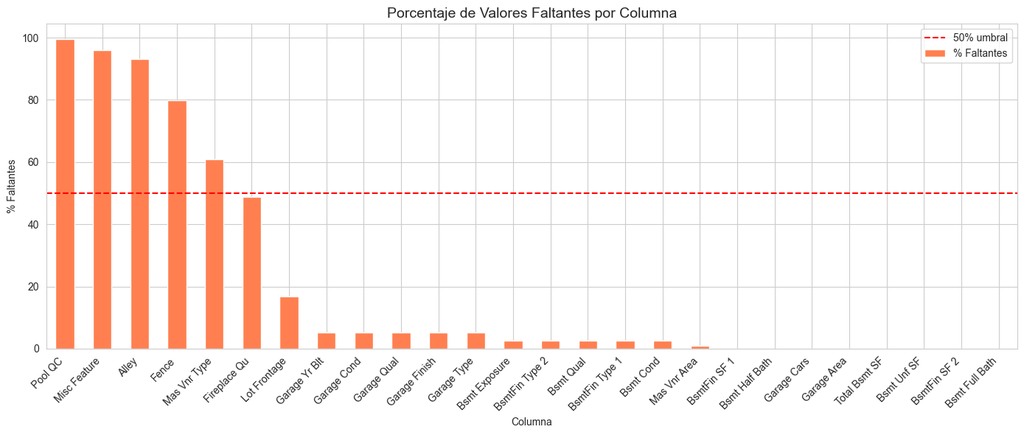

```python
# Visualización de valores faltantes
if len(missing_df) > 0:
    fig, ax = plt.subplots(figsize=(14, 6))
    missing_df['% Faltantes'].plot(kind='bar', color='coral', ax=ax)
    ax.set_title('Porcentaje de Valores Faltantes por Columna', fontsize=14)
    ax.set_ylabel('% Faltantes')
    ax.set_xlabel('Columna')
    ax.axhline(y=50, color='red', linestyle='--', label='50% umbral')
    ax.legend()
    plt.xticks(rotation=45, ha='right')
    plt.tight_layout()
    plt.show()
```

### 3.3 Análisis de la Variable Objetivo (SalePrice)

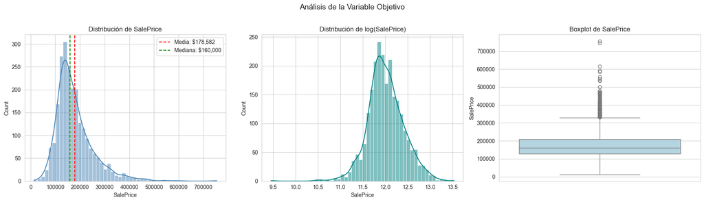

```
Media:     $178,582.21
Mediana:   $160,000.00
Desv. Std: $77,125.07
Skewness:  1.7506
Kurtosis:  5.4745
```

```python
fig, axes = plt.subplots(1, 3, figsize=(18, 5))

# Distribución
sns.histplot(df['SalePrice'], kde=True, bins=50, ax=axes[0], color='steelblue')
axes[0].set_title('Distribución de SalePrice')
axes[0].axvline(df['SalePrice'].mean(), color='red', linestyle='--', label=f'Media: ${df["SalePrice"].mean():,.0f}')
axes[0].axvline(df['SalePrice'].median(), color='green', linestyle='--', label=f'Mediana: ${df["SalePrice"].median():,.0f}')
axes[0].legend()

# Distribución log
sns.histplot(np.log1p(df['SalePrice']), kde=True, bins=50, ax=axes[1], color='teal')
axes[1].set_title('Distribución de log(SalePrice)')

# Boxplot
sns.boxplot(y=df['SalePrice'], ax=axes[2], color='lightblue')
axes[2].set_title('Boxplot de SalePrice')

plt.suptitle('Análisis de la Variable Objetivo', fontsize=14, y=1.02)
plt.tight_layout()
plt.show()

print(f'Media:     ${df["SalePrice"].mean():,.2f}')
print(f'Mediana:   ${df["SalePrice"].median():,.2f}')
print(f'Desv. Std: ${df["SalePrice"].std():,.2f}')
print(f'Skewness:  {df["SalePrice"].skew():.4f}')
print(f'Kurtosis:  {df["SalePrice"].kurtosis():.4f}')
```

**Observación:** La distribución de `SalePrice` presenta sesgo positivo (right-skewed). La transformación logarítmica produce una distribución más cercana a la normal, lo cual puede beneficiar ciertos modelos de regresión.

### 3.4 Variables Numéricas – Distribuciones y Outliers

```python
num_cols = df.select_dtypes(include=[np.number]).columns.tolist()
num_cols_no_target = [c for c in num_cols if c != 'SalePrice']

print(f'Variables numéricas (sin target): {len(num_cols_no_target)}')
print(num_cols_no_target)
```

```
Variables numéricas (sin target): 36
['MS SubClass', 'Lot Frontage', 'Lot Area', 'Overall Qual', 'Overall Cond', 'Year Built', 'Year Remod/Add', 'Mas Vnr Area', 'BsmtFin SF 1', 'BsmtFin SF 2', 'Bsmt Unf SF', 'Total Bsmt SF', '1st Flr SF', '2nd Flr SF', 'Low Qual Fin SF', 'Gr Liv Area', 'Bsmt Full Bath', 'Bsmt Half Bath', 'Full Bath', '…
```

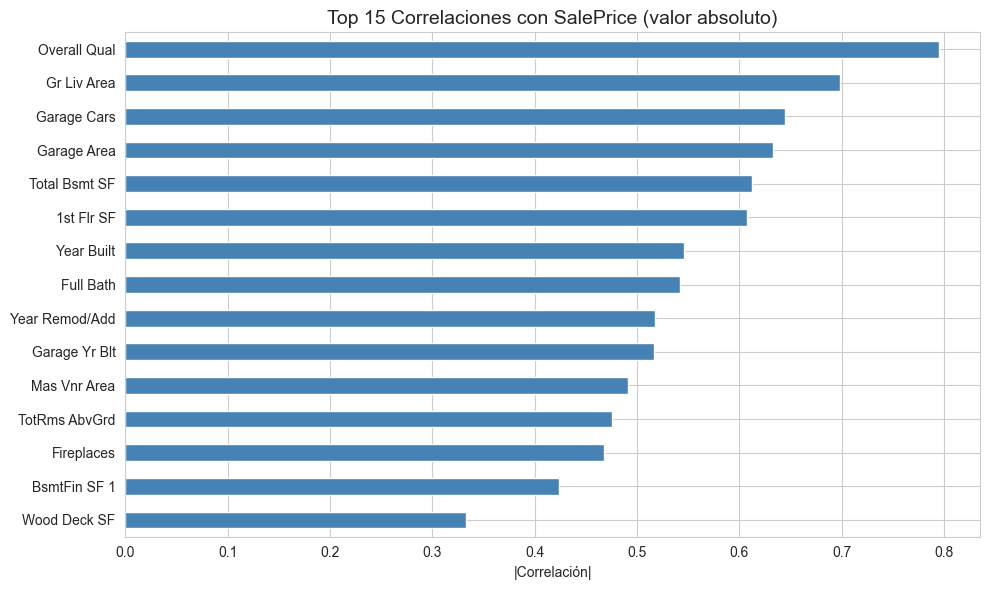

```
Top 15 correlaciones:
  Overall Qual        : 0.7953
  Gr Liv Area         : 0.6983
  Garage Cars         : 0.6443
  Garage Area         : 0.6331
  Total Bsmt SF       : 0.6123
  1st Flr SF          : 0.6074
  Year Built          : 0.5454
  Full Bath           : 0.5421
  Year Remod/Add      : 0.5177
  Garage Yr Blt       : 0.5162
  Mas Vnr Area        : 0.4909
  TotRms AbvGrd       : 0.4755
  Fireplaces          : 0.4675
  BsmtFin SF 1        : 0.4239
  Wood Deck SF        : 0.3330
```

```python
# Top 15 correlaciones con SalePrice
corr_with_target = df[num_cols].corr()['SalePrice'].drop('SalePrice').abs().sort_values(ascending=False)
top_corr = corr_with_target.head(15)

fig, ax = plt.subplots(figsize=(10, 6))
top_corr.plot(kind='barh', color='steelblue', ax=ax)
ax.set_title('Top 15 Correlaciones con SalePrice (valor absoluto)', fontsize=14)
ax.set_xlabel('|Correlación|')
ax.invert_yaxis()
plt.tight_layout()
plt.show()

print('\nTop 15 correlaciones:')
for feat, corr in top_corr.items():
    print(f'  {feat:20s}: {corr:.4f}')
```

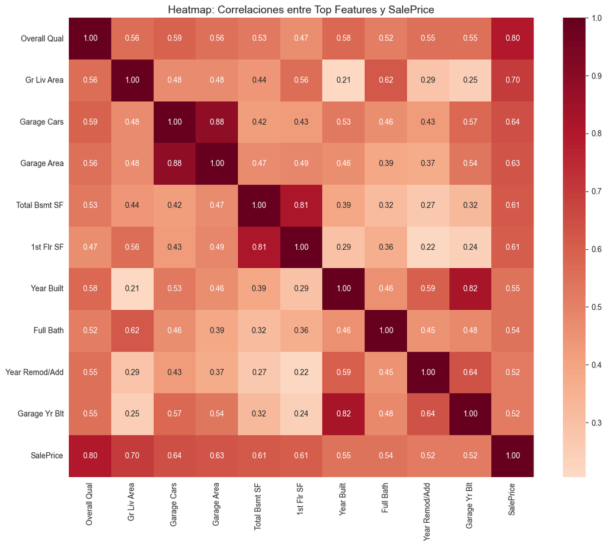

```python
# Heatmap de las variables más correlacionadas
top_features = top_corr.head(10).index.tolist() + ['SalePrice']
fig, ax = plt.subplots(figsize=(12, 10))
sns.heatmap(df[top_features].corr(), annot=True, fmt='.2f', cmap='RdBu_r', center=0, ax=ax)
ax.set_title('Heatmap: Correlaciones entre Top Features y SalePrice', fontsize=14)
plt.tight_layout()
plt.show()
```

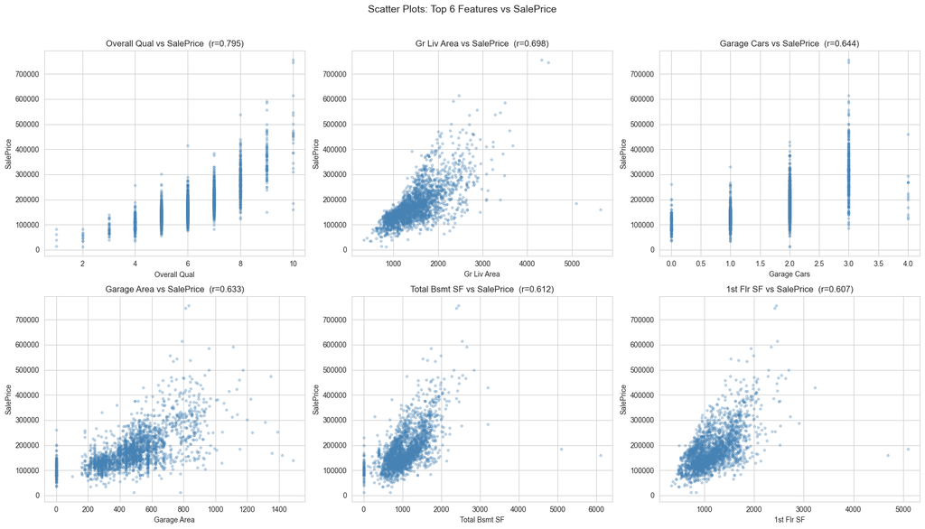

```python
# Scatter plots de las 6 variables más correlacionadas
top6 = corr_with_target.head(6).index.tolist()
fig, axes = plt.subplots(2, 3, figsize=(18, 10))
for i, col in enumerate(top6):
    row, col_idx = i // 3, i % 3
    axes[row, col_idx].scatter(df[col], df['SalePrice'], alpha=0.3, s=10, color='steelblue')
    axes[row, col_idx].set_xlabel(col)
    axes[row, col_idx].set_ylabel('SalePrice')
    axes[row, col_idx].set_title(f'{col} vs SalePrice  (r={df[col].corr(df["SalePrice"]):.3f})')
plt.suptitle('Scatter Plots: Top 6 Features vs SalePrice', fontsize=14, y=1.02)
plt.tight_layout()
plt.show()
```

### 3.5 Variables Categóricas

```python
cat_cols = df.select_dtypes(include=['object']).columns.tolist()
print(f'Variables categóricas: {len(cat_cols)}')

# Cardinalidad de cada variable categórica
cat_card = pd.DataFrame({
    'Categoría': cat_cols,
    'Cardinalidad': [df[c].nunique() for c in cat_cols],
    '% Faltantes': [(df[c].isnull().sum() / len(df)) * 100 for c in cat_cols]
}).sort_values('Cardinalidad', ascending=False)

cat_card
```

```
Variables categóricas: 43
```

|  | Categoría | Cardinalidad | % Faltantes |
| --- | --- | --- | --- |
| 8 | Neighborhood | 28 | 0.000000 |
| 15 | Exterior 1st | 16 | 0.000000 |
| 16 | Exterior 2nd | 16 | 0.000000 |
| 41 | Sale Type | 10 | 0.000000 |
| 9 | Condition 1 | 9 | 0.000000 |
| 31 | Functional | 8 | 0.000000 |
| 10 | Condition 2 | 8 | 0.000000 |
| 12 | House Style | 8 | 0.000000 |
| 14 | Roof Matl | 8 | 0.000000 |
| 0 | MS Zoning | 7 | 0.000000 |
| 33 | Garage Type | 6 | 5.119454 |
| 26 | Heating | 6 | 0.000000 |
| 25 | BsmtFin Type 2 | 6 | 2.645051 |
| 24 | BsmtFin Type 1 | 6 | 2.602389 |
| 20 | Foundation | 6 | 0.000000 |
| 42 | Sale Condition | 6 | 0.000000 |
| 13 | Roof Style | 6 | 0.000000 |
| 6 | Lot Config | 5 | 0.000000 |
| 36 | Garage Cond | 5 | 5.204778 |
| 35 | Garage Qual | 5 | 5.204778 |
| 32 | Fireplace Qu | 5 | 48.805461 |
| 27 | Heating QC | 5 | 0.000000 |
| 29 | Electrical | 5 | 0.000000 |
| 21 | Bsmt Qual | 5 | 2.602389 |
| 11 | Bldg Type | 5 | 0.000000 |
| 22 | Bsmt Cond | 5 | 2.602389 |
| 19 | Exter Cond | 5 | 0.000000 |
| 40 | Misc Feature | 4 | 95.989761 |
| 39 | Fence | 4 | 79.948805 |
| 38 | Pool QC | 4 | 99.488055 |
| 18 | Exter Qual | 4 | 0.000000 |
| 23 | Bsmt Exposure | 4 | 2.687713 |
| 4 | Land Contour | 4 | 0.000000 |
| 30 | Kitchen Qual | 4 | 0.000000 |
| 17 | Mas Vnr Type | 4 | 60.836177 |
| 3 | Lot Shape | 4 | 0.000000 |
| 7 | Land Slope | 3 | 0.000000 |
| 34 | Garage Finish | 3 | 5.204778 |
| 37 | Paved Drive | 3 | 0.000000 |
| 5 | Utilities | 3 | 0.000000 |
| 28 | Central Air | 2 | 0.000000 |
| 1 | Street | 2 | 0.000000 |
| 2 | Alley | 2 | 93.088737 |

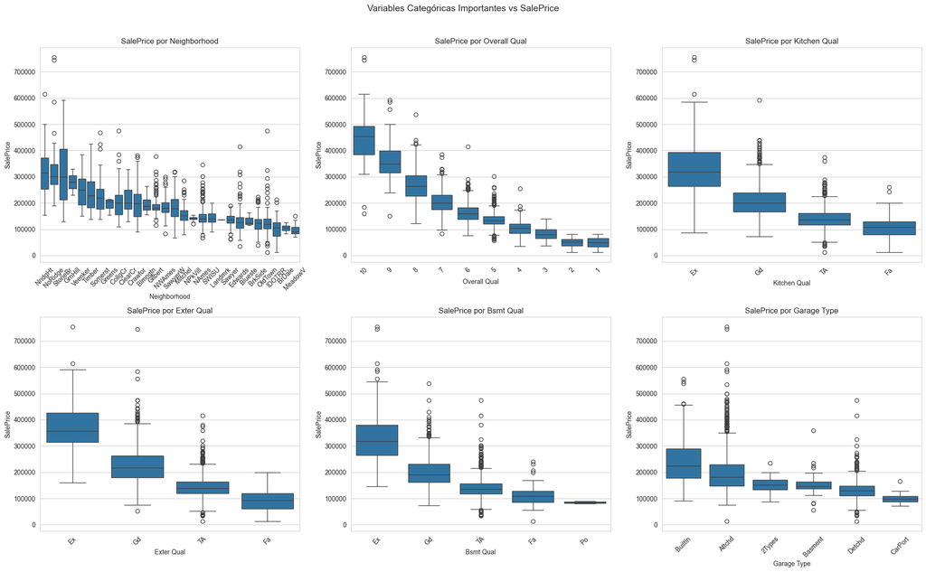

```python
# Boxplots de las categóricas más relevantes vs SalePrice
important_cats = ['Neighborhood', 'Overall Qual', 'Kitchen Qual', 'Exter Qual', 'Bsmt Qual', 'Garage Type']
# Filtrar solo las que existen en el df
important_cats = [c for c in important_cats if c in df.columns]

fig, axes = plt.subplots(2, 3, figsize=(20, 12))
for i, col in enumerate(important_cats[:6]):
    row, col_idx = i // 3, i % 3
    order = df.groupby(col)['SalePrice'].median().sort_values(ascending=False).index
    sns.boxplot(x=col, y='SalePrice', data=df, ax=axes[row, col_idx], order=order)
    axes[row, col_idx].set_title(f'SalePrice por {col}')
    axes[row, col_idx].tick_params(axis='x', rotation=45)

plt.suptitle('Variables Categóricas Importantes vs SalePrice', fontsize=14, y=1.02)
plt.tight_layout()
plt.show()
```

### 3.6 Resumen del EDA

**Hallazgos principales:**

- **SalePrice** tiene distribución sesgada a la derecha; usaremos log-transform para mejorar predicciones.
- Las variables más correlacionadas con `SalePrice` son: `Overall Qual`, `Gr Liv Area`, `Garage Area`, `Garage Cars`, `Total Bsmt SF`, `1st Flr SF`.
- Columnas como `Pool QC`, `Misc Feature`, `Alley`, `Fence` tienen >40% de valores faltantes (muchos NaN significan "no aplica").
- Variables categóricas como `Neighborhood`, `Kitchen Qual`, `Exter Qual` muestran diferencias significativas en precio mediano.

## 4. Preprocesamiento de Datos

### 4.1 Selección de Variables

**Criterios de eliminación:**

1. Columnas con >40% de valores faltantes: difícil imputar de forma confiable.
2. Columnas con varianza casi nula o cardinalidad = 1.
3. Columnas redundantes o de muy baja correlación con el target.

```python
# Separar X e y
X = features.copy()
y = target['SalePrice'].copy()

print(f'Shape inicial X: {X.shape}')
print(f'Shape y: {y.shape}')

# 1. Eliminar columnas con >40% de valores faltantes
threshold = 0.40
missing_ratio = X.isnull().sum() / len(X)
cols_to_drop_missing = missing_ratio[missing_ratio > threshold].index.tolist()
print(f'\nColumnas con >{threshold*100:.0f}% faltantes (se eliminan): {cols_to_drop_missing}')
X = X.drop(columns=cols_to_drop_missing)

# 2. Eliminar columnas con varianza casi nula
low_var_cols = []
for col in X.select_dtypes(include=['object']).columns:
    if X[col].nunique() <= 1:
        low_var_cols.append(col)
for col in X.select_dtypes(include=[np.number]).columns:
    if X[col].std() == 0:
        low_var_cols.append(col)

if low_var_cols:
    print(f'Columnas con varianza ~0 (se eliminan): {low_var_cols}')
    X = X.drop(columns=low_var_cols)

print(f'\nShape después de selección: {X.shape}')
```

```
Shape inicial X: (2344, 79)
Shape y: (2344,)

Columnas con >40% faltantes (se eliminan): ['Alley', 'Mas Vnr Type', 'Fireplace Qu', 'Pool QC', 'Fence', 'Misc Feature']

Shape después de selección: (2344, 73)
```

### 4.2 Identificación de Tipos de Variables

```python
# Separar columnas numéricas y categóricas
numerical_cols = X.select_dtypes(include=[np.number]).columns.tolist()
categorical_cols = X.select_dtypes(include=['object']).columns.tolist()

# Variables ordinales (tienen un orden natural de calidad/condición)
ordinal_cols = []
ordinal_mappings = {}

# Mapeos ordinales para variables de calidad/condición
quality_map = {'Po': 0, 'Fa': 1, 'TA': 2, 'Gd': 3, 'Ex': 4}
quality_vars = ['Exter Qual', 'Exter Cond', 'Heating QC', 'Kitchen Qual',
                'Bsmt Qual', 'Bsmt Cond', 'Garage Qual', 'Garage Cond']

for col in quality_vars:
    if col in categorical_cols:
        ordinal_cols.append(col)
        ordinal_mappings[col] = quality_map

# Otras variables ordinales
other_ordinal = {
    'Bsmt Exposure': {'No': 0, 'Mn': 1, 'Av': 2, 'Gd': 3},
    'BsmtFin Type 1': {'Unf': 0, 'LwQ': 1, 'Rec': 2, 'BLQ': 3, 'ALQ': 4, 'GLQ': 5},
    'BsmtFin Type 2': {'Unf': 0, 'LwQ': 1, 'Rec': 2, 'BLQ': 3, 'ALQ': 4, 'GLQ': 5},
    'Functional': {'Sal': 0, 'Sev': 1, 'Maj2': 2, 'Maj1': 3, 'Mod': 4, 'Min2': 5, 'Min1': 6, 'Typ': 7},
    'Garage Finish': {'Unf': 0, 'RFn': 1, 'Fin': 2},
    'Paved Drive': {'N': 0, 'P': 1, 'Y': 2},
    'Central Air': {'N': 0, 'Y': 1},
    'Land Slope': {'Sev': 0, 'Mod': 1, 'Gtl': 2},
    'Lot Shape': {'IR3': 0, 'IR2': 1, 'IR1': 2, 'Reg': 3},
}

for col, mapping in other_ordinal.items():
    if col in categorical_cols:
        ordinal_cols.append(col)
        ordinal_mappings[col] = mapping

# Variables nominales = categóricas que quedan después de las ordinales
nominal_cols = [c for c in categorical_cols if c not in ordinal_cols]

print(f'Variables numéricas:  {len(numerical_cols)}')
print(f'Variables ordinales:  {len(ordinal_cols)}')
print(f'Variables nominales:  {len(nominal_cols)}')
print(f'Total:                {len(numerical_cols) + len(ordinal_cols) + len(nominal_cols)}')
print(f'\nOrdinales: {ordinal_cols}')
print(f'\nNominales: {nominal_cols}')
```

```
Variables numéricas:  36
Variables ordinales:  17
Variables nominales:  20
Total:                73

Ordinales: ['Exter Qual', 'Exter Cond', 'Heating QC', 'Kitchen Qual', 'Bsmt Qual', 'Bsmt Cond', 'Garage Qual', 'Garage Cond', 'Bsmt Exposure', 'BsmtFin Type 1', 'BsmtFin Type 2', 'Functional', 'Garage Finish', 'Paved Drive', 'Central Air', 'Land Slope', 'Lot Shape']

Nominales: ['MS Zoning', 'Street', 'Land Contour', 'Utilities', 'Lot Config', 'Neighborhood', 'Condition 1', 'Condition 2', 'Bldg Type', 'House Style', 'Roof Style', 'Roof Matl', 'Exterior 1st', 'Exterior 2nd', 'Foundation', 'Heating', 'Electrical', 'Garage Type', 'Sale Type', 'Sale Condition']
```

### 4.3 Pipeline de Preprocesamiento

**Estrategia de imputación:**

- **Numéricas:** Mediana (robusta a outliers)
- **Categóricas ordinales:** Moda (valor más frecuente), luego mapeo ordinal
- **Categóricas nominales:** Moda, luego One-Hot Encoding

**Justificación:**

- Muchos NaN en variables de sótano/garaje significan "no tiene", la imputación por moda/mediana maneja esto.
- One-Hot para nominales evita imponer orden artificial.
- Ordinal encoding para variables de calidad respeta su orden natural.
- Standard scaling para numéricas (necesario para modelos regularizados).

```python
# Aplicar mapeo ordinal manualmente antes del pipeline
# (para tener control total sobre el orden)
X_processed = X.copy()

for col in ordinal_cols:
    mapping = ordinal_mappings[col]
    X_processed[col] = X_processed[col].map(mapping)

# Ahora las ordinales se tratan como numéricas
final_numerical = numerical_cols + ordinal_cols
final_nominal = nominal_cols

print(f'Columnas numéricas (incluye ordinales mapeadas): {len(final_numerical)}')
print(f'Columnas nominales (para One-Hot):               {len(final_nominal)}')
```

```
Columnas numéricas (incluye ordinales mapeadas): 53
Columnas nominales (para One-Hot):               20
```

```python
# Construir Pipeline de transformación
numeric_transformer = Pipeline(steps=[
    ('imputer', SimpleImputer(strategy='median')),
    ('scaler', StandardScaler())
])

nominal_transformer = Pipeline(steps=[
    ('imputer', SimpleImputer(strategy='most_frequent')),
    ('onehot', OneHotEncoder(handle_unknown='ignore', sparse_output=False))
])

preprocessor = ColumnTransformer(
    transformers=[
        ('num', numeric_transformer, final_numerical),
        ('nom', nominal_transformer, final_nominal)
    ],
    remainder='drop'
)

print('Pipeline de preprocesamiento creado.')
print(preprocessor)
```

```
Pipeline de preprocesamiento creado.
ColumnTransformer(transformers=[('num',
                                 Pipeline(steps=[('imputer',
                                                  SimpleImputer(strategy='median')),
                                                 ('scaler', StandardScaler())]),
                                 ['MS SubClass', 'Lot Frontage', 'Lot Area',
                                  'Overall Qual', 'Overall Cond', 'Year Built',
                                  'Year Remod/Add', 'Mas Vnr Area',
                                  'BsmtFin SF 1', 'BsmtFin SF 2', 'Bsmt Unf SF',
                                  'Total Bsmt SF', '1st Flr SF', '2nd Flr SF',
                                  'Low Qual Fin SF', 'Gr Liv Area',
                                  'Bsmt Full Bat...
                                                  SimpleImputer(strategy='most_frequent')),
                                                 ('onehot',
                                                  OneHotEncoder(handle_unknown='ignore',
                                                                sparse_output=False))]),
                                 ['MS Zoning', 'Street', 'Land Contour',
                                  'Utilities', 'Lot Config', 'Neighborhood',
                                  'Condition 1', 'Condition 2', 'Bldg Type',
                                  'House Style', 'Roof Style', 'Roof Matl',
                                  'Exterior 1st', 'Exterior 2nd', 'Foundation',
                                  'Heating', 'Electrical', 'Garage Type',
                                  'Sale Type', 'Sale Condition'])])
```

### 4.4 División de Datos: Entrenamiento y Validación

```python
# Aplicar log-transform a SalePrice para mejorar la distribución
y_log = np.log1p(y)

# División 80/20 estratificada por cuantiles de precio
X_train, X_val, y_train, y_val = train_test_split(
    X_processed, y_log, test_size=0.2, random_state=42
)

print(f'Conjunto de entrenamiento: {X_train.shape[0]} filas')
print(f'Conjunto de validación:    {X_val.shape[0]} filas')
print(f'\nProporción: {X_train.shape[0]/len(X_processed)*100:.1f}% / {X_val.shape[0]/len(X_processed)*100:.1f}%')
```

```
Conjunto de entrenamiento: 1875 filas
Conjunto de validación:    469 filas

Proporción: 80.0% / 20.0%
```

```python
# Ajustar y transformar
X_train_transformed = preprocessor.fit_transform(X_train)
X_val_transformed = preprocessor.transform(X_val)

print(f'X_train transformado: {X_train_transformed.shape}')
print(f'X_val transformado:   {X_val_transformed.shape}')
```

```
X_train transformado: (1875, 212)
X_val transformado:   (469, 212)
```

## 5. Entrenamiento de Modelos

Entrenaremos múltiples modelos de regresión y compararemos su rendimiento.

### 5.1 Modelo 1: Ridge Regression

```python
# Ridge Regression con búsqueda de hiperparámetros
ridge_params = {'alpha': [0.01, 0.1, 1, 5, 10, 50, 100]}
ridge_grid = GridSearchCV(
    Ridge(), ridge_params, cv=5, scoring='neg_mean_squared_error', n_jobs=-1
)
ridge_grid.fit(X_train_transformed, y_train)

print(f'Mejor alpha: {ridge_grid.best_params_["alpha"]}')
print(f'Mejor MSE (CV, log-scale): {-ridge_grid.best_score_:.6f}')
print(f'Mejor RMSE (CV, log-scale): {np.sqrt(-ridge_grid.best_score_):.6f}')

ridge_best = ridge_grid.best_estimator_
```

```
Mejor alpha: 100
Mejor MSE (CV, log-scale): 0.024816
Mejor RMSE (CV, log-scale): 0.157531
```

### 5.2 Modelo 2: Lasso Regression

```python
# Lasso Regression
lasso_params = {'alpha': [0.0001, 0.0005, 0.001, 0.005, 0.01, 0.05, 0.1]}
lasso_grid = GridSearchCV(
    Lasso(max_iter=10000), lasso_params, cv=5, scoring='neg_mean_squared_error', n_jobs=-1
)
lasso_grid.fit(X_train_transformed, y_train)

print(f'Mejor alpha: {lasso_grid.best_params_["alpha"]}')
print(f'Mejor MSE (CV, log-scale): {-lasso_grid.best_score_:.6f}')
print(f'Mejor RMSE (CV, log-scale): {np.sqrt(-lasso_grid.best_score_):.6f}')

lasso_best = lasso_grid.best_estimator_

# Número de coeficientes no-cero (feature selection)
n_nonzero = np.sum(lasso_best.coef_ != 0)
print(f'\nCoeficientes no-cero: {n_nonzero} de {X_train_transformed.shape[1]}')
```

```
Mejor alpha: 0.0005
Mejor MSE (CV, log-scale): 0.024121
Mejor RMSE (CV, log-scale): 0.155308

Coeficientes no-cero: 101 de 212
```

### 5.3 Modelo 3: ElasticNet

```python
# ElasticNet
enet_params = {
    'alpha': [0.0005, 0.001, 0.005, 0.01, 0.05],
    'l1_ratio': [0.1, 0.3, 0.5, 0.7, 0.9]
}
enet_grid = GridSearchCV(
    ElasticNet(max_iter=10000), enet_params, cv=5, scoring='neg_mean_squared_error', n_jobs=-1
)
enet_grid.fit(X_train_transformed, y_train)

print(f'Mejores params: {enet_grid.best_params_}')
print(f'Mejor MSE (CV, log-scale): {-enet_grid.best_score_:.6f}')
print(f'Mejor RMSE (CV, log-scale): {np.sqrt(-enet_grid.best_score_):.6f}')

enet_best = enet_grid.best_estimator_
```

```
Mejores params: {'alpha': 0.0005, 'l1_ratio': 0.9}
Mejor MSE (CV, log-scale): 0.024153
Mejor RMSE (CV, log-scale): 0.155413
```

### 5.4 Modelo 4: Random Forest

```python
# Random Forest Regressor
rf_params = {
    'n_estimators': [100, 200, 300],
    'max_depth': [10, 15, 20, None],
    'min_samples_split': [2, 5],
    'min_samples_leaf': [1, 2]
}
rf_grid = GridSearchCV(
    RandomForestRegressor(random_state=42), rf_params, cv=5,
    scoring='neg_mean_squared_error', n_jobs=-1, verbose=0
)
rf_grid.fit(X_train_transformed, y_train)

print(f'Mejores params: {rf_grid.best_params_}')
print(f'Mejor MSE (CV, log-scale): {-rf_grid.best_score_:.6f}')
print(f'Mejor RMSE (CV, log-scale): {np.sqrt(-rf_grid.best_score_):.6f}')

rf_best = rf_grid.best_estimator_
```

```
Mejores params: {'max_depth': None, 'min_samples_leaf': 2, 'min_samples_split': 2, 'n_estimators': 300}
Mejor MSE (CV, log-scale): 0.023367
Mejor RMSE (CV, log-scale): 0.152864
```

### 5.5 Modelo 5: Gradient Boosting

```python
# Gradient Boosting Regressor
gb_params = {
    'n_estimators': [200, 300, 500],
    'learning_rate': [0.01, 0.05, 0.1],
    'max_depth': [3, 4, 5],
    'min_samples_split': [2, 5],
    'subsample': [0.8, 1.0]
}
gb_grid = GridSearchCV(
    GradientBoostingRegressor(random_state=42), gb_params, cv=5,
    scoring='neg_mean_squared_error', n_jobs=-1, verbose=0
)
gb_grid.fit(X_train_transformed, y_train)

print(f'Mejores params: {gb_grid.best_params_}')
print(f'Mejor MSE (CV, log-scale): {-gb_grid.best_score_:.6f}')
print(f'Mejor RMSE (CV, log-scale): {np.sqrt(-gb_grid.best_score_):.6f}')

gb_best = gb_grid.best_estimator_
```

```
Mejores params: {'learning_rate': 0.05, 'max_depth': 4, 'min_samples_split': 2, 'n_estimators': 500, 'subsample': 0.8}
Mejor MSE (CV, log-scale): 0.018445
Mejor RMSE (CV, log-scale): 0.135812
```

## 6. Comparación de Modelos

### 6.1 Evaluación en Conjunto de Validación

```python
models = {
    'Ridge': ridge_best,
    'Lasso': lasso_best,
    'ElasticNet': enet_best,
    'Random Forest': rf_best,
    'Gradient Boosting': gb_best
}

results = []

for name, model in models.items():
    # Predicciones en log-scale
    y_pred_log = model.predict(X_val_transformed)

    # Convertir a escala original
    y_pred = np.expm1(y_pred_log)
    y_val_original = np.expm1(y_val)

    # Métricas en escala original (USD)
    mse = mean_squared_error(y_val_original, y_pred)
    rmse = np.sqrt(mse)
    mae = mean_absolute_error(y_val_original, y_pred)
    r2 = r2_score(y_val_original, y_pred)

    # MSE en log-scale (para CV comparison)
    mse_log = mean_squared_error(y_val, y_pred_log)

    results.append({
        'Modelo': name,
        'MSE (USD)': mse,
        'RMSE (USD)': rmse,
        'MAE (USD)': mae,
        'R²': r2,
        'MSE (log)': mse_log
    })

results_df = pd.DataFrame(results).sort_values('MSE (USD)')
results_df.index = range(1, len(results_df) + 1)

print('='*80)
print('COMPARACIÓN DE MODELOS - Conjunto de Validación')
print('='*80)
results_df
```

```
================================================================================
COMPARACIÓN DE MODELOS - Conjunto de Validación
================================================================================
```

|  | Modelo | MSE (USD) | RMSE (USD) | MAE (USD) | R² | MSE (log) |
| --- | --- | --- | --- | --- | --- | --- |
| 1 | Gradient Boosting | 3.117909e+08 | 17657.602031 | 12342.365511 | 0.942684 | 0.010462 |
| 2 | ElasticNet | 3.736132e+08 | 19329.077568 | 13974.126837 | 0.931320 | 0.016374 |
| 3 | Lasso | 3.749998e+08 | 19364.910818 | 14008.047127 | 0.931065 | 0.016478 |
| 4 | Ridge | 3.980772e+08 | 19951.871524 | 14459.438758 | 0.926823 | 0.016269 |
| 5 | Random Forest | 4.154985e+08 | 20383.781293 | 14498.055432 | 0.923620 | 0.014065 |

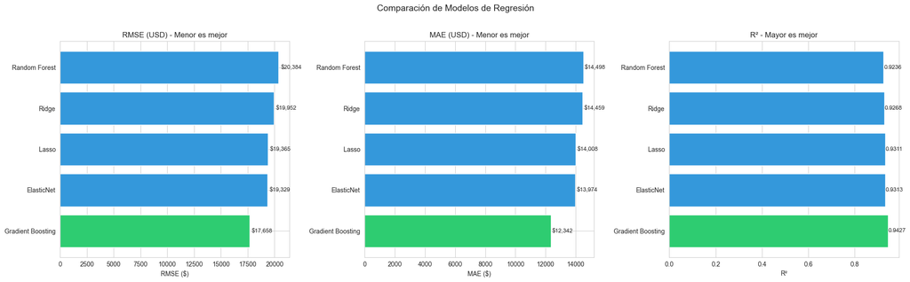

```python
# Visualización de comparación
fig, axes = plt.subplots(1, 3, figsize=(20, 6))

colors = ['#2ecc71' if i == 0 else '#3498db' for i in range(len(results_df))]

# RMSE
axes[0].barh(results_df['Modelo'], results_df['RMSE (USD)'], color=colors)
axes[0].set_title('RMSE (USD) - Menor es mejor', fontsize=12)
axes[0].set_xlabel('RMSE ($)')
for i, v in enumerate(results_df['RMSE (USD)']):
    axes[0].text(v + 200, i, f'${v:,.0f}', va='center', fontsize=9)

# MAE
axes[1].barh(results_df['Modelo'], results_df['MAE (USD)'], color=colors)
axes[1].set_title('MAE (USD) - Menor es mejor', fontsize=12)
axes[1].set_xlabel('MAE ($)')
for i, v in enumerate(results_df['MAE (USD)']):
    axes[1].text(v + 100, i, f'${v:,.0f}', va='center', fontsize=9)

# R²
axes[2].barh(results_df['Modelo'], results_df['R²'], color=colors)
axes[2].set_title('R² - Mayor es mejor', fontsize=12)
axes[2].set_xlabel('R²')
for i, v in enumerate(results_df['R²']):
    axes[2].text(v + 0.002, i, f'{v:.4f}', va='center', fontsize=9)

plt.suptitle('Comparación de Modelos de Regresión', fontsize=14, y=1.02)
plt.tight_layout()
plt.show()
```

### 6.2 Predicciones vs Valores Reales

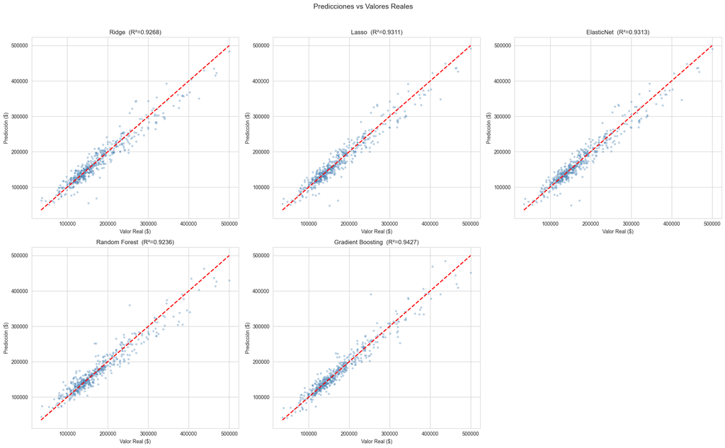

```python
# Scatter plots: Predicciones vs Reales para cada modelo
fig, axes = plt.subplots(2, 3, figsize=(20, 12))
y_val_original = np.expm1(y_val)

for i, (name, model) in enumerate(models.items()):
    row, col = i // 3, i % 3
    y_pred = np.expm1(model.predict(X_val_transformed))

    axes[row, col].scatter(y_val_original, y_pred, alpha=0.3, s=10, color='steelblue')

    # Línea de predicción perfecta
    min_val = min(y_val_original.min(), y_pred.min())
    max_val = max(y_val_original.max(), y_pred.max())
    axes[row, col].plot([min_val, max_val], [min_val, max_val], 'r--', linewidth=2)

    r2 = r2_score(y_val_original, y_pred)
    axes[row, col].set_title(f'{name}  (R²={r2:.4f})')
    axes[row, col].set_xlabel('Valor Real ($)')
    axes[row, col].set_ylabel('Predicción ($)')

# Ocultar último subplot vacío
axes[1, 2].set_visible(False)

plt.suptitle('Predicciones vs Valores Reales', fontsize=14, y=1.02)
plt.tight_layout()
plt.show()
```

### 6.3 Cross-Validation Completa

```python
# Cross-validation en todo el conjunto de entrenamiento
X_all_transformed = preprocessor.fit_transform(X_processed)

cv_results = []
for name, model in models.items():
    scores = cross_val_score(model, X_all_transformed, y_log, cv=10,
                             scoring='neg_mean_squared_error', n_jobs=-1)
    rmse_scores = np.sqrt(-scores)
    cv_results.append({
        'Modelo': name,
        'RMSE Mean (log)': rmse_scores.mean(),
        'RMSE Std (log)': rmse_scores.std(),
        'MSE Mean (log)': (-scores).mean()
    })

cv_df = pd.DataFrame(cv_results).sort_values('RMSE Mean (log)')
cv_df.index = range(1, len(cv_df) + 1)

print('='*80)
print('CROSS-VALIDATION (10-fold) - Log Scale')
print('='*80)
cv_df
```

```
================================================================================
CROSS-VALIDATION (10-fold) - Log Scale
================================================================================
```

|  | Modelo | RMSE Mean (log) | RMSE Std (log) | MSE Mean (log) |
| --- | --- | --- | --- | --- |
| 1 | Gradient Boosting | 0.120428 | 0.014937 | 0.014726 |
| 2 | ElasticNet | 0.136375 | 0.029026 | 0.019441 |
| 3 | Lasso | 0.136558 | 0.029367 | 0.019511 |
| 4 | Ridge | 0.138652 | 0.028387 | 0.020030 |
| 5 | Random Forest | 0.141417 | 0.014306 | 0.020203 |

## 7. Selección del Mejor Modelo y Persistencia

### 7.1 Selección del Mejor Modelo

```python
# Seleccionar el mejor modelo basado en MSE de validación
best_model_name = results_df.iloc[0]['Modelo']
best_model = models[best_model_name]

best_mse = results_df.iloc[0]['MSE (USD)']
best_rmse = results_df.iloc[0]['RMSE (USD)']
best_r2 = results_df.iloc[0]['R²']

print('='*60)
print(f'MEJOR MODELO: {best_model_name}')
print('='*60)
print(f'MSE:  ${best_mse:,.2f}')
print(f'RMSE: ${best_rmse:,.2f}')
print(f'R²:   {best_r2:.4f}')
print(f'\nParámetros del modelo:')
print(best_model.get_params())
```

```
============================================================
MEJOR MODELO: Gradient Boosting
============================================================
MSE:  $311,790,909.49
RMSE: $17,657.60
R²:   0.9427

Parámetros del modelo:
{'alpha': 0.9, 'ccp_alpha': 0.0, 'criterion': 'friedman_mse', 'init': None, 'learning_rate': 0.05, 'loss': 'squared_error', 'max_depth': 4, 'max_features': None, 'max_leaf_nodes': None, 'min_impurity_decrease': 0.0, 'min_samples_leaf': 1, 'min_samples_split': 2, 'min_weight_fraction_leaf': 0.0, 'n_e…
```

**Justificación de la selección:**

Se selecciona el modelo con el menor MSE en el conjunto de validación, ya que MSE es la métrica de evaluación del concurso. Además, se verifica que el modelo tenga buen desempeño en cross-validation (baja varianza) para asegurar generalización.

### 7.2 Re-entrenamiento con Todos los Datos

```python
# Re-entrenar el mejor modelo con TODOS los datos de entrenamiento
X_all_transformed = preprocessor.fit_transform(X_processed)
best_model.fit(X_all_transformed, y_log)

print(f'Modelo {best_model_name} re-entrenado con {X_all_transformed.shape[0]} filas y {X_all_transformed.shape[1]} features.')
```

```
Modelo Gradient Boosting re-entrenado con 2344 filas y 217 features.
```

### 7.3 Guardar Modelo con Pickle

```python
# Guardar el pipeline completo + modelo
# Empaquetamos todo lo necesario para hacer predicciones sobre datos nuevos
model_package = {
    'model': best_model,
    'preprocessor': preprocessor,
    'ordinal_cols': ordinal_cols,
    'ordinal_mappings': ordinal_mappings,
    'columns_to_drop': cols_to_drop_missing + low_var_cols,
    'model_name': best_model_name,
    'log_transform': True  # Recordar que se usó log1p en y
}

with open('best_model.pkl', 'wb') as f:
    pickle.dump(model_package, f)

print(f'Modelo guardado como: best_model.pkl')
print(f'Contenido del paquete: {list(model_package.keys())}')
```

```
Modelo guardado como: best_model.pkl
Contenido del paquete: ['model', 'preprocessor', 'ordinal_cols', 'ordinal_mappings', 'columns_to_drop', 'model_name', 'log_transform']
```

### 7.4 Pipeline de Predicción para Datos Nuevos

Esta función aplica todas las transformaciones necesarias a nuevos datos de test y genera predicciones.

```python
def predict_new_data(test_features_path, model_path='best_model.pkl'):
    """
    Función para predecir SalePrice sobre datos nuevos de test.

    Parámetros:
    -----------
    test_features_path : str
        Ruta al archivo CSV con las features de test.
    model_path : str
        Ruta al archivo pickle del modelo.

    Retorna:
    --------
    predictions : np.array
        Predicciones de SalePrice en escala original (USD).
    """
    # Cargar modelo
    with open(model_path, 'rb') as f:
        package = pickle.load(f)

    model = package['model']
    preprocessor = package['preprocessor']
    ordinal_cols = package['ordinal_cols']
    ordinal_mappings = package['ordinal_mappings']
    columns_to_drop = package['columns_to_drop']
    log_transform = package['log_transform']

    # Cargar datos de test
    X_test = pd.read_csv(test_features_path)

    # Eliminar columnas seleccionadas
    cols_to_drop = [c for c in columns_to_drop if c in X_test.columns]
    X_test = X_test.drop(columns=cols_to_drop)

    # Aplicar mapeo ordinal
    for col in ordinal_cols:
        if col in X_test.columns:
            mapping = ordinal_mappings[col]
            X_test[col] = X_test[col].map(mapping)

    # Transformar con preprocessor
    X_test_transformed = preprocessor.transform(X_test)

    # Predecir
    y_pred_log = model.predict(X_test_transformed)

    # Convertir a escala original si se usó log-transform
    if log_transform:
        predictions = np.expm1(y_pred_log)
    else:
        predictions = y_pred_log

    return predictions

print('Función predict_new_data() definida y lista para usar.')
print('\nUso:')
print("  predictions = predict_new_data('test_features.csv')")
```

```
Función predict_new_data() definida y lista para usar.

Uso:
  predictions = predict_new_data('test_features.csv')
```

### 7.5 Verificación del Modelo Guardado

```python
# Verificar que el modelo guardado funciona correctamente
with open('best_model.pkl', 'rb') as f:
    loaded_package = pickle.load(f)

loaded_model = loaded_package['model']
loaded_preprocessor = loaded_package['preprocessor']

# Probar con los primeros 5 datos de entrenamiento
X_sample = X_processed.head(5)
X_sample_transformed = loaded_preprocessor.transform(X_sample)
y_pred_sample = np.expm1(loaded_model.predict(X_sample_transformed))
y_real_sample = y.head(5).values

verification_df = pd.DataFrame({
    'SalePrice Real': [f'${v:,.0f}' for v in y_real_sample],
    'SalePrice Predicción': [f'${v:,.0f}' for v in y_pred_sample],
    'Error (%)': [f'{abs(r-p)/r*100:.1f}%' for r, p in zip(y_real_sample, y_pred_sample)]
})

print('Verificación del modelo cargado desde pickle:')
print(f'Modelo: {loaded_package["model_name"]}')
print()
verification_df
```

```
Verificación del modelo cargado desde pickle:
Modelo: Gradient Boosting
```

|  | SalePrice Real | SalePrice Predicción | Error (%) |
| --- | --- | --- | --- |
| 0 | $152,000 | $144,169 | 5.2% |
| 1 | $185,000 | $179,631 | 2.9% |
| 2 | $101,800 | $99,724 | 2.0% |
| 3 | $90,000 | $90,864 | 1.0% |
| 4 | $94,550 | $94,607 | 0.1% |